# Презентация лабораторной работы №9

Настройка POP3/IMAP сервера

Устинова В. В.

Российский университет дружбы народов, Москва, Россия

31 октября 2026

# Информация

## Докладчик

- Устинова Виктория Вадимовна
- студент НПИбд-01-24
- Российский университет дружбы народов

# Вводная часть

## Цель работы

Приобретение практических навыков по установке и простейшему конфигурированию POP3/IMAP-сервера.

## Задание

1. Установить на виртуальной машине server Dovecot и Telnet для дальнейшей проверки корректности работы почтового сервера.
2. Настроить Dovecot.
3. Установить на виртуальной машине client программу для чтения почты Evolution и настроить её для работы с почтой своего пользователя. Проверить корректность работы почтового сервера как с виртуальной машины server, так и с виртуальной машины client.
4. Изменить скрипт для Vagrant, фиксирующий действия по установке и настройке Postfix и Dovecot на виртуальной машине server, создать скрипт для Vagrant, фиксирующий установку Evolution на виртуальной машине client, и внести соответствующие изменения в Vagrantfile.

# Выполнение лабораторной работы

## Протоколы и аутентификация

В `/etc/dovecot/dovecot.conf` добавлена строка `protocols = imap pop3`. В `10-auth.conf` проверен метод аутентификации `auth_mechanisms = plain`, в `auth-system.conf.ext` для проверки паролей используется драйвер pam.

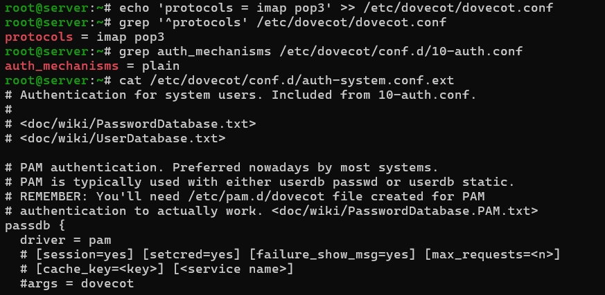

Настройка списка протоколов и проверка метода аутентификации и драйвера pam

## Файл auth-system.conf.ext

Блок `passdb` с драйвером passwd, предназначенный для системных пользователей, закомментирован. Проверка паролей выполняется только через PAM.

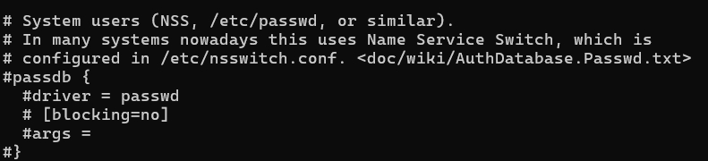

Продолжение файла auth-system.conf.ext: блок passdb с драйвером passwd закомментирован

## Почтовые ящики и межсетевой экран

В `10-mail.conf` задано `mail_location = maildir:~/Maildir`, в Postfix — `home_mailbox = Maildir/`. В межсетевом экране разрешены службы pop3, pop3s, imap и imaps, затем восстановлен контекст SELinux и перезапущен Postfix.

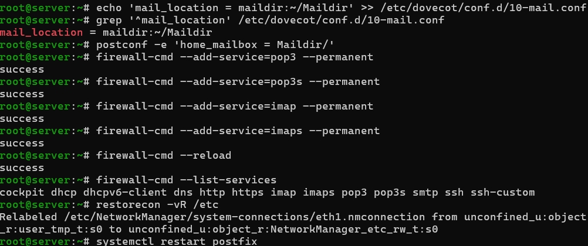

Настройка расположения почтовых ящиков, каталога доставки Postfix и межсетевого экрана

## Запуск Dovecot

Dovecot включён в автозапуск и запущен. Статус службы: active (running), версия 2.3.21.

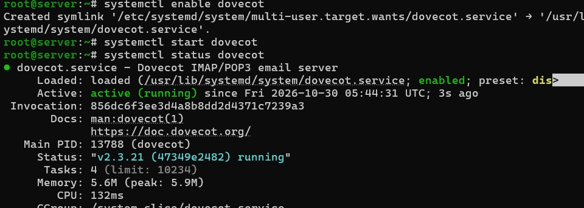

Запуск и проверка состояния службы Dovecot

## Проверка на сервере

С сервера отправлено письмо test1, оно найдено в каталоге Maildir командой `mail`. Командой `doveadm mailbox list` выведен список ящиков пользователя, в нём есть INBOX.

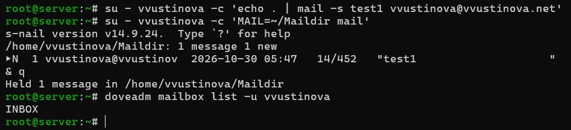

Отправка письма test1, просмотр почты в Maildir и список ящиков командой doveadm

## Evolution: учётная запись

На виртуальной машине client установлен почтовый клиент Evolution. При настройке указаны имя Victoria и адрес `vvustinova@vvustinova.net`.

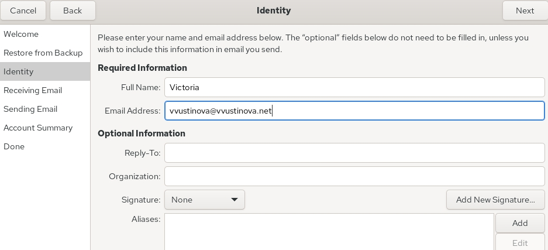

Настройка учётной записи в Evolution: имя и адрес электронной почты

## Evolution: получение почты

Для входящих сообщений выбран сервер IMAP `mail.vvustinova.net`, порт 143, пользователь vvustinova, шифрование STARTTLS, аутентификация по паролю.

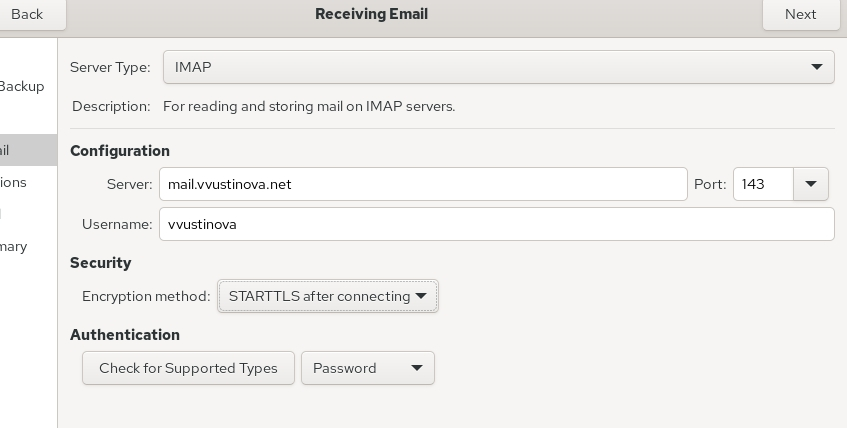

Настройка получения почты в Evolution по протоколу IMAP

## Evolution: отправка почты

Для исходящих сообщений выбран сервер SMTP `mail.vvustinova.net`, порт 25, шифрование и аутентификация сервера не используются.

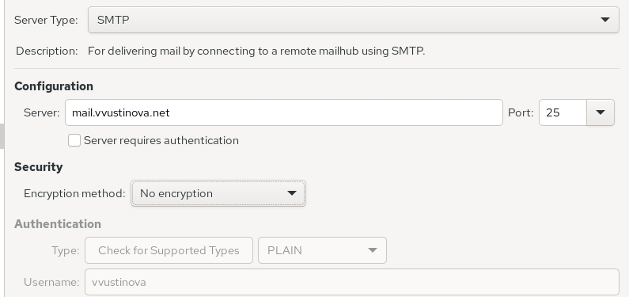

Настройка отправки почты в Evolution по протоколу SMTP

## Тестовое письмо из Evolution

Из почтового клиента отправлено письмо самому себе с темой test1.

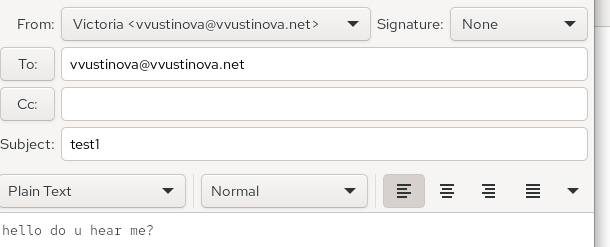

Тестовое письмо, отправленное из Evolution

## Журнал почтовой службы

Dovecot сообщает об успешном входе пользователя vvustinova по IMAP с адреса клиента 192.168.1.30 (метод PLAIN, TLS). Postfix принимает письмо по SMTP и доставляет его со статусом `status=sent (delivered to maildir)`.

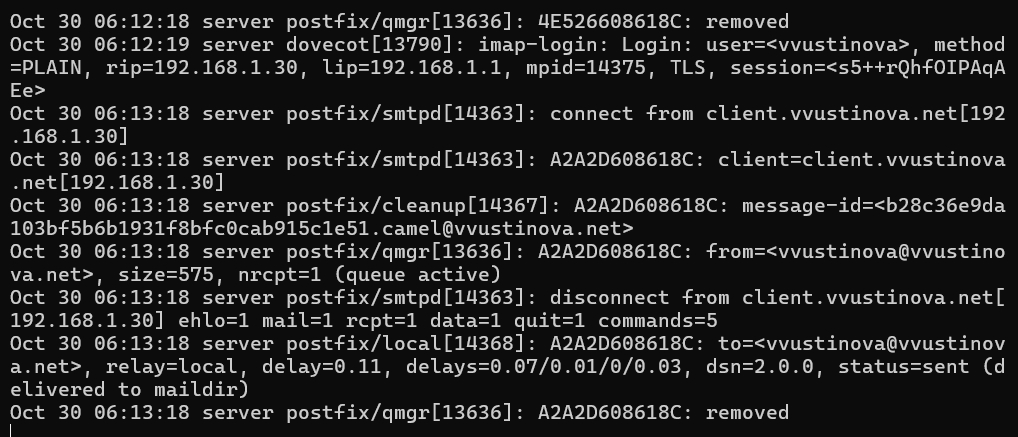

Журнал maillog: вход по IMAP и доставка письма в Maildir

## Проверка по POP3

В ящике пользователя оказалось три непрочитанных письма: одно с сервера и два из Evolution. Через telnet выполнено подключение к `mail.vvustinova.net` на порт 110, сервер ответил `+OK Dovecot ready`, вход выполнен, введена команда `list`.

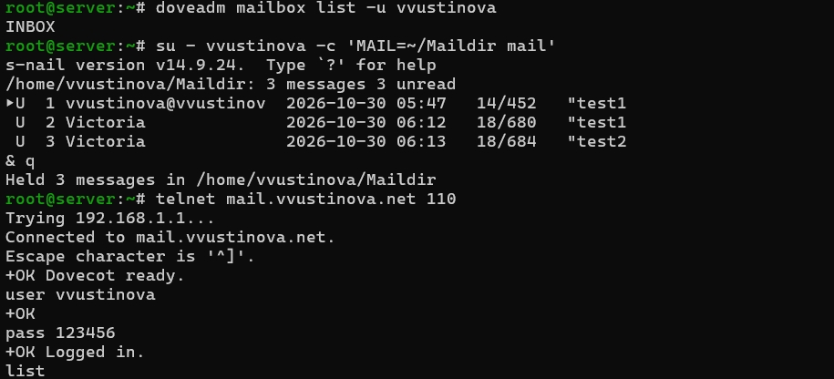

Список ящиков и писем на сервере, подключение по протоколу POP3 через telnet

## Скрипт mail.sh для сервера

В скрипт добавлена установка пакетов dovecot и telnet, копирование конфигурационных файлов из каталога provision и разрешение служб pop3 и pop3s в межсетевом экране, остальные строки добавлены по заданию.

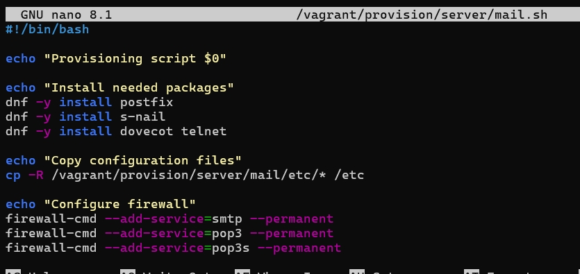

Скрипт mail.sh виртуальной машины server

## Скрипт mail.sh для клиента

В скрипт клиента добавлена установка почтового клиента Evolution.

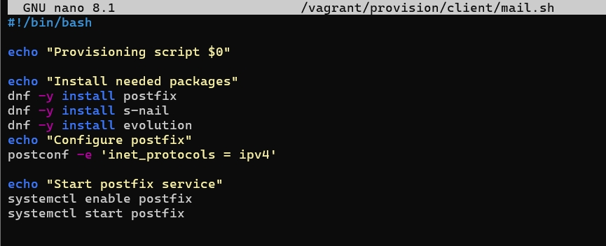

Скрипт mail.sh виртуальной машины client

# Заключение

## Выводы

В ходе работы получены практические навыки по установке и простейшему конфигурированию POP3/IMAP-сервера Dovecot. Dovecot настроен на работу по протоколам IMAP и POP3 с хранением почты в формате Maildir, а Postfix настроен на доставку писем в тот же каталог. С клиента через Evolution отправлены письма и получен доступ к ящику по IMAP, на сервере работа проверена командами mail, doveadm, анализом журнала и подключением по POP3 через telnet. Действия по настройке зафиксированы в скриптах `mail.sh` для сервера и клиента.